# AS05_survey_presentation

Chia Chi Hong

```r
library(forcats) # 處理 factor 排序的好幫手
```

```r
library(cowplot)
library(scales) # ✨ 新增這個套件：專門處理百分比與座標軸格式
library(ggplot2)
library(grid)
library(readxl)
library(tidyverse)
library(showtext)
library(stringr)
# options(stringsAsFactors = F)

# font_add_google("Noto Sans TC", "NotoSans")
font_add_google("Roboto Condensed", "roboto_condensed")
showtext_auto()

# Define The Economist Design System
econ_red <- "#E3120B"
econ_red60 <- "#F6423C"
econ_red_tok90 <- "#F9D2DB"
econ_blue_chi45 <- "#2E45B8"
econ_grey_lon70 <- "#B3B3B3"
econ_canvas_los90 <- "#EBE9E0"
text_lon10 <- "#1A1A1A"
caption <- "#595959"
```

# 1 Introduction

在當今的台灣，對於「假訊息（Fake News）」的討論已成為日常。然而，民眾對於假訊息的焦慮程度究竟有多高？不同世代的群體，是否都同樣感受到假訊息的嚴重威脅？而當我們試圖揪出民眾認為的「造假元兇」時，不同教育程度與政治立場的選民，認知又是否一致？

為了解答這些問題，本篇報導採用**「台灣事實查核中心 2023 年假訊息年度調查」**之公開數據。本次分析萃取並重新編碼了以下八個核心變數：

- **影響認知：** `Q3` 覺得假訊息對社會的影響嚴不嚴重？
- **假消息來源（頻率評估）：**
  - `Q4_1` 媒體工作者
  - `Q4_2` 政治人物
  - `Q4_3` 一般民眾
  - `Q4_4` 境外勢力
- **社會人口特徵：**
  - `QA3` 年齡
  - `QA4` 最高學歷
  - `QASide` 政黨傾向

接下來的篇幅，將呈現數據清理、資料分析與製圖過程。

（以上文字為 Gemini 協助撰寫第一版後，再經由我編輯。）

# 2 Data

## 2.1 Data cleaning

```r
raw <- read_csv("data/AS05_tfc_2023.csv")
# View(raw)
```

```r
clean <- raw %>%
  slice(-1) %>%

  select(
    Q3,
    Q4_1, Q4_2, Q4_3, Q4_4,
    QASide,
    QA3,
    QA4,
    QA16) %>%

  mutate(across(everything(), as.numeric)) %>%

  mutate(
    # Q3 (假消息嚴重程度)
    Q3_factor = factor(Q3,
                       levels = c(1, 2, 3, 4),
                       labels = c("一點也不嚴重", "不嚴重", "嚴重", "非常嚴重"),
                       ordered = TRUE),

    # QASide：政黨傾向 (排除 99 拒答，並按照藍綠光譜排序)
    QASide_factor = factor(QASide,
                           levels = c(1, 4, 3, 5, 2),
                           labels = c("非常接近泛藍", "接近泛藍", "都不接近", "接近泛綠", "非常接近泛綠")),

    # QA3：年齡
    QA3_factor = factor(QA3,
                        levels = 1:12,
                        labels = c("19及以下", "20-24", "25-29", "30-34", "35-39",
                                   "40-44", "45-49", "50-54", "55-59", "60-64",
                                   "65-69", "70及以上"),
                        ordered = TRUE),

    # QA4：最高學歷 (排除99拒答)
    QA4_factor = factor(QA4,
                        levels = 1:5,
                        labels = c("國小及以下", "國中", "高中職", "大專", "研究所及以上"),
                        ordered = TRUE),

    # QA16：疫苗劑量
    QA16_factor = factor(QA16,
                         levels = 1:7,
                         labels = c("沒有接種", "1劑", "2劑", "3劑", "4劑", "5劑", "6劑以上"),
                         ordered = TRUE)
    )

head(clean)

# anyNA(clean) # False

# Q4_1 到 Q4_4, long form，for Stacked Bar chart
q4_long <- clean %>%
    select(Q4_1:Q4_4) %>%

    pivot_longer(cols = everything(), names_to = "Source", values_to = "Frequency") %>%

    mutate(
        Source = factor(Source,
                        levels = c("Q4_1", "Q4_2", "Q4_3", "Q4_4"),
                        labels = c("媒體工作者", "政治人物", "一般民眾", "境外勢力")),

        Frequency_factor = factor(Frequency,
                              levels = c(1, 2, 3, 4),
                              labels = c("從未製造", "偶而", "經常", "每天"),
                              ordered = TRUE)
  )

head(q4_long)
```

```
#> # A tibble: 6 × 14
#>      Q3  Q4_1  Q4_2  Q4_3  Q4_4 QASide   QA3   QA4  QA16 Q3_factor QASide_factor
#>   <dbl> <dbl> <dbl> <dbl> <dbl>  <dbl> <dbl> <dbl> <dbl> <ord>     <fct>
#> 1     4     3     4     2     2      5     4     4     6 非常嚴重  接近泛綠
#> 2     4     3     3     2     2      5     3     4     4 非常嚴重  接近泛綠
#> 3     3     2     1     3     4      5     4     4     3 嚴重      接近泛綠
#> 4     3     3     3     2     3      5     2     4     4 嚴重      接近泛綠
#> 5     3     4     4     2     3      4     5     4     3 嚴重      接近泛藍
#> 6     3     3     3     3     3      4     6     4     5 嚴重      接近泛藍
#> # ℹ 3 more variables: QA3_factor <ord>, QA4_factor <ord>, QA16_factor <ord>
#> # A tibble: 6 × 3
#>   Source     Frequency Frequency_factor
#>   <fct>          <dbl> <ord>
#> 1 媒體工作者         3 經常
#> 2 政治人物           4 每天
#> 3 一般民眾           2 偶而
#> 4 境外勢力           2 偶而
#> 5 媒體工作者         3 經常
#> 6 政治人物           3 經常
```

## 2.2 Recode

從次數與百分比分布，確認是否簡化各題 Levels 與 Labels

### 2.2.1 Q3 假消息嚴重程度

```r
table(clean$Q3_factor)
prop.table(table(clean$Q3_factor)) %>% round(3)
```

```
#>
#> 一點也不嚴重       不嚴重         嚴重     非常嚴重
#>           14          109         1154          512
#>
#> 一點也不嚴重       不嚴重         嚴重     非常嚴重
#>        0.008        0.061        0.645        0.286
```

### 2.2.2 QASide 政黨傾向

```r
table(clean$QASide_factor)
prop.table(table(clean$QASide_factor)) %>% round(3)
```

```
#>
#> 非常接近泛藍     接近泛藍     都不接近     接近泛綠 非常接近泛綠
#>          100          648            0          899          142
#>
#> 非常接近泛藍     接近泛藍     都不接近     接近泛綠 非常接近泛綠
#>        0.056        0.362        0.000        0.503        0.079
```

### 2.2.3 QA3 年齡

```r
table(clean$QA3_factor)
prop.table(table(clean$QA3_factor)) %>% round(3)
```

```
#>
#> 19及以下    20-24    25-29    30-34    35-39    40-44    45-49    50-54
#>        0      154      192      188      215      413      175      137
#>    55-59    60-64    65-69 70及以上
#>       85      111       75       44
#>
#> 19及以下    20-24    25-29    30-34    35-39    40-44    45-49    50-54
#>    0.000    0.086    0.107    0.105    0.120    0.231    0.098    0.077
#>    55-59    60-64    65-69 70及以上
#>    0.048    0.062    0.042    0.025
```

### 2.2.4 QA4 最高學歷

```r
table(clean$QA4_factor)
prop.table(table(clean$QA4_factor)) %>% round(3)
```

```
#>
#>   國小及以下         國中       高中職         大專 研究所及以上
#>           31           46          197         1105          410
#>
#>   國小及以下         國中       高中職         大專 研究所及以上
#>        0.017        0.026        0.110        0.618        0.229
```

### 2.2.5 QA16 疫苗劑量

```r
table(clean$QA16)
prop.table(table(clean$QA16)) %>% round(3)
```

```
#>
#>    1    2    3    4    5    6    7
#>   71   39  152 1011  398  104   14
#>
#>     1     2     3     4     5     6     7
#> 0.040 0.022 0.085 0.565 0.222 0.058 0.008
```

### 2.2.6 Recode

```r
clean_recode <- clean %>%
    mutate(
        # Q3：合併不嚴重的極端值
        Q3_factor = fct_collapse(Q3_factor,
                                 "不嚴重" = c("一點也不嚴重", "不嚴重"),
                                 "嚴重" = "嚴重",
                                 "非常嚴重" = "非常嚴重"),

        # QASide：先清掉0人的類別，再合併成兩大陣營
        QASide_factor = fct_drop(QASide_factor),
        # QASide_factor = fct_collapse(QASide_factor,
        #                              "泛藍" = c("非常接近泛藍", "接近泛藍"),
        #                              "泛綠" = c("接近泛綠", "非常接近泛綠")),

        # QA3：清除0人世代，並合併為10歲區間
        QA3_factor = fct_drop(QA3_factor),
        QA3_factor = fct_collapse(QA3_factor,
                                  "20-29" = c("20-24", "25-29"),
                                  "30-39" = c("30-34", "35-39"),
                                  "40-49" = c("40-44", "45-49"),
                                  "50-59" = c("50-54", "55-59"),
                                  "60-69" = c("60-64", "65-69"),
                                  "70+" = "70及以上"),

        # QA4：學歷合併
        QA4_factor = fct_collapse(QA4_factor,
                                  "高中職及以下" = c("國小及以下", "國中", "高中職"),
                                  "大專" = "大專",
                                  "研究所及以上" = "研究所及以上"),

        # QA16：疫苗合併
        QA16_factor = fct_collapse(QA16_factor,
                                   "沒有接種" = "沒有接種",
                                   "1或2劑" = c("1劑", "2劑"),
                                   "3劑以上" = c("3劑", "4劑", "5劑", "6劑以上")),


        across(Q4_1:Q4_4, ~factor(.x, levels = c(1, 2, 3, 4),
                                      labels = c("Never", "Occasionally", "Often", "Daily"),
                                      ordered = TRUE), .names = "{.col}_en")) %>%

    select(
        Q3_factor,
        QASide_factor,
        QA3_factor,
        QA4_factor,
        QA16_factor,
        Q4_1_en:Q4_4_en)

head(clean_recode)
```

```
#> # A tibble: 6 × 9
#>   Q3_factor QASide_factor QA3_factor QA4_factor QA16_factor Q4_1_en      Q4_2_en
#>   <ord>     <fct>         <ord>      <ord>      <ord>       <ord>        <ord>
#> 1 非常嚴重  接近泛綠      30-39      大專       3劑以上     Often        Daily
#> 2 非常嚴重  接近泛綠      20-29      大專       3劑以上     Often        Often
#> 3 嚴重      接近泛綠      30-39      大專       1或2劑      Occasionally Never
#> 4 嚴重      接近泛綠      20-29      大專       3劑以上     Often        Often
#> 5 嚴重      接近泛藍      30-39      大專       1或2劑      Daily        Daily
#> 6 嚴重      接近泛藍      40-49      大專       3劑以上     Often        Often
#> # ℹ 2 more variables: Q4_3_en <ord>, Q4_4_en <ord>
```

# 3 Results

## 3.1 請問您覺得假消息對社會的影響嚴不嚴重？（Q3）

```r
q3_en_summary <- clean_recode %>%
    count(Q3_factor, name = "count") %>%
    mutate(
        pct = count / sum(count),
        Q3_en = case_when(
            Q3_factor == "不嚴重" ~ "Not serious",
            Q3_factor == "嚴重" ~ "Serious",
            Q3_factor == "非常嚴重" ~ "Very serious"),
        Q3_en = fct_reorder(Q3_en, pct, .desc = F))

q3_en_summary
```

```
#> # A tibble: 3 × 4
#>   Q3_factor count    pct Q3_en
#>   <ord>     <int>  <dbl> <fct>
#> 1 不嚴重      123 0.0688 Not serious
#> 2 嚴重       1154 0.645  Serious
#> 3 非常嚴重    512 0.286  Very serious
```

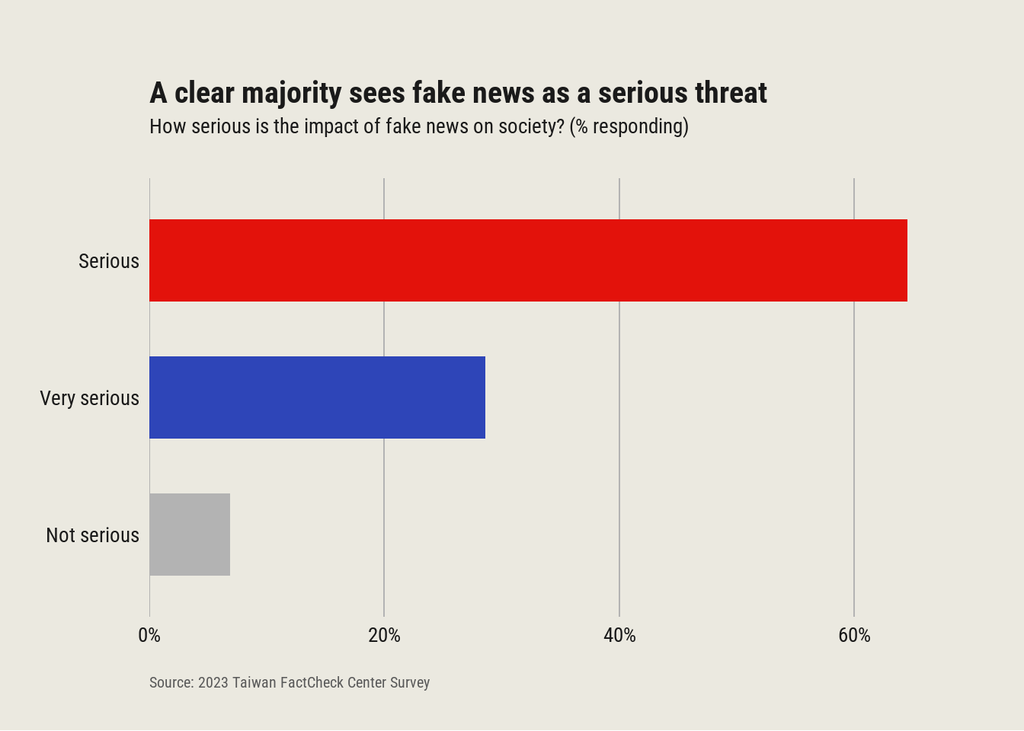

```r
plot_q3_en <-
    ggplot(
        q3_en_summary,
        aes(x = pct, y = Q3_en, fill = Q3_en)) +

    geom_col(width = 0.6) +

    scale_fill_manual(values = c("Serious" = econ_red,
                                 "Very serious" = econ_blue_chi45,
                                 "Not serious" = econ_grey_lon70))  +

    # X 軸百分比格式
    scale_x_continuous(labels = percent_format(accuracy = 1),
                       expand = expansion(mult = c(0, 0.1))) +


    # 英文標題與說明
    labs(
        title = "A clear majority sees fake news as a serious threat",
        subtitle = "How serious is the impact of fake news on society? (% responding)",
        x = NULL, y = NULL,
        caption = "Source: 2023 Taiwan FactCheck Center Survey") +


    theme_minimal() +

    theme(

        text = element_text(family = "roboto_condensed", color = text_lon10),

        legend.position = "none",

        plot.title = element_text(face = "bold",
                                  size = 30,
                                  hjust = 0,
                                  margin = margin(t = 15, b = 5)),

        plot.subtitle = element_text(size = 20,
                                     hjust = 0,
                                     margin = margin(b = 20)),

        plot.caption = element_text(size = 15,
                                    color = caption,
                                    hjust = 0,
                                    margin = margin(t = 15)),


        # 座標軸文字
        axis.text.y = element_text(size = 20, color = text_lon10),
        axis.text.x = element_text(size = 20, color = text_lon10),


        # 網格與背景
        panel.grid.major.x = element_line(color = econ_grey_lon70, size = 0.5),
        panel.grid.major.y = element_blank(),
        panel.grid.minor = element_blank(),
        plot.background = element_rect(fill = econ_canvas_los90, color = NA),
        panel.background = element_rect(fill = econ_canvas_los90, color = NA),
        plot.margin = margin(t = 25, r = 20, b = 20, l = 20)
        )
plot_q3_en
```

## 3.2 請問您覺得假消息對社會的影響嚴不嚴重？（Q3）X 年紀（QA3）

```r
cross_age_data <- clean_recode %>%
    mutate(
        Age = as.character(QA3_factor),
        Age = case_when(
            Age == "20-29" ~ "20-29",
            Age == "30-39" ~ "30-39",
            Age == "40-49" ~ "40-49",
            Age == "50-59" ~ "50-59",
            Age == "60-69" ~ "60-69",
            Age == "70+" ~ "70+"),
        Age = factor(Age, levels = c("20-29", "30-39", "40-49", "50-59", "60-69", "70+")),

        Severity_en = case_when(
            Q3_factor == "不嚴重" ~ "Not serious",
            Q3_factor == "嚴重" ~ "Serious",
            Q3_factor == "非常嚴重" ~ "Very serious"),
        Severity_en = factor(Severity_en, levels = c("Not serious", "Serious", "Very serious"), ordered = TRUE)
  ) %>%

  count(Age, Severity_en) %>%
  group_by(Age) %>%
  mutate(pct = n / sum(n)) %>%
  ungroup()

cross_age_data
```

```
#> # A tibble: 17 × 4
#>    Age   Severity_en      n    pct
#>    <fct> <ord>        <int>  <dbl>
#>  1 20-29 Not serious     19 0.0549
#>  2 20-29 Serious        220 0.636
#>  3 20-29 Very serious   107 0.309
#>  4 30-39 Not serious     32 0.0794
#>  5 30-39 Serious        258 0.640
#>  6 30-39 Very serious   113 0.280
#>  7 40-49 Not serious     36 0.0612
#>  8 40-49 Serious        383 0.651
#>  9 40-49 Very serious   169 0.287
#> 10 50-59 Not serious     23 0.104
#> 11 50-59 Serious        135 0.608
#> 12 50-59 Very serious    64 0.288
#> 13 60-69 Not serious     13 0.0699
#> 14 60-69 Serious        128 0.688
#> 15 60-69 Very serious    45 0.242
#> 16 70+   Serious         30 0.682
#> 17 70+   Very serious    14 0.318
```

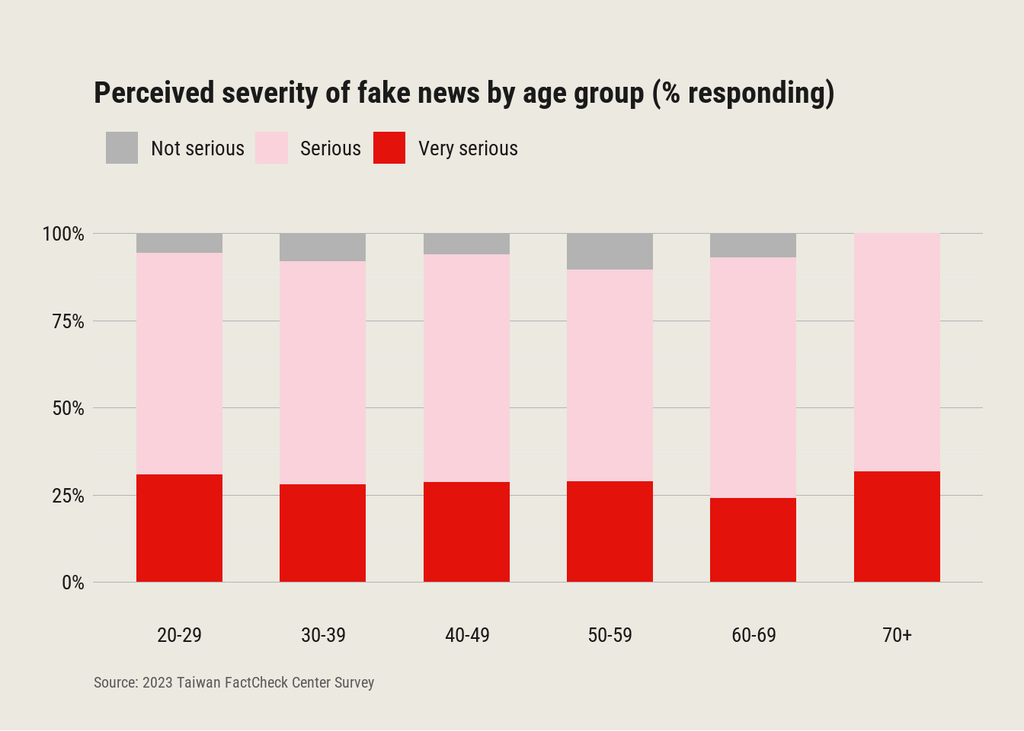

```r
plot_age_vertical <- ggplot(
    cross_age_data,
    aes(x = Age, y = pct, fill = Severity_en)) +

    geom_col(width = 0.6) +

    scale_fill_manual(values = c("Very serious" = econ_red,
                                 "Serious" = econ_red_tok90,
                                 "Not serious" = econ_grey_lon70)) +

    scale_y_continuous(labels = percent_format(accuracy = 1), expand = c(0, 0.1)) +

    labs(
        title = "Perceived severity of fake news by age group (% responding)",
        x = NULL, y = NULL,
        caption = "Source: 2023 Taiwan FactCheck Center Survey") +

    theme_minimal() +

    theme(
        text = element_text(family = "roboto_condensed", color = text_lon10),

        legend.position = "top",
        legend.justification = "left",
        legend.title = element_blank(),
        legend.text = element_text(size = 20),
        legend.color = text_lon10,

        plot.title = element_text(face = "bold",
                                  size = 30,
                                  hjust = 0,
                                  margin = margin(t = 15, b = 5)),

        plot.caption = element_text(size = 15,
                                    color = caption,
                                    hjust = 0,
                                    margin = margin(t = 15)),

        axis.text.x = element_text(size = 20, color = text_lon10),
        axis.text.y = element_text(size = 20, color = text_lon10),

        panel.grid.major.y = element_line(color = econ_grey_lon70, size = 0.3),
        panel.grid.major.x = element_blank(),

        plot.background = element_rect(fill = econ_canvas_los90, color = NA),
        panel.background = element_rect(fill = econ_canvas_los90, color = NA),
        plot.margin = margin(t = 25, r = 20, b = 20, l = 20)
        )

plot_age_vertical
```

## 3.3 請問您認為以下個人或團體是否經常在製造假消息？（Q4_1 - Q4_4）

Q4_1 到 Q4_4 題目中的「個人或團體」分別指媒體工作者、政治人物、一般民眾、境外勢力。

```r
q4_summary_pct <- q4_long %>%

    mutate(
        Source_en = case_when(
        Source == "媒體工作者" ~ "News Media",
        Source == "政治人物" ~ "Politicians",
        Source == "一般民眾" ~ "Citizens",
        Source == "境外勢力" ~ "Foreign Forces"
        ),

    Freq_en = case_when(
        Frequency_factor == "從未製造" ~ "Never",
        Frequency_factor == "偶而" ~ "Occasionally",
        Frequency_factor == "經常" ~ "Often",
        Frequency_factor == "每天" ~ "Daily"
        ),

    Freq_en = factor(Freq_en,
                     levels = c("Never", "Occasionally", "Often", "Daily"),
                     ordered = TRUE)) %>%

    # 計算每個 Source 裡面的百分比
    count(Source_en, Freq_en) %>%
    group_by(Source_en) %>%
    mutate(pct = n / sum(n)) %>%
    ungroup()

q4_summary_pct
```

```
#> # A tibble: 16 × 4
#>    Source_en      Freq_en          n     pct
#>    <chr>          <ord>        <int>   <dbl>
#>  1 Citizens       Never           26 0.0145
#>  2 Citizens       Occasionally  1066 0.596
#>  3 Citizens       Often          562 0.314
#>  4 Citizens       Daily          135 0.0755
#>  5 Foreign Forces Never           15 0.00838
#>  6 Foreign Forces Occasionally   500 0.279
#>  7 Foreign Forces Often          821 0.459
#>  8 Foreign Forces Daily          453 0.253
#>  9 News Media     Never           14 0.00783
#> 10 News Media     Occasionally   488 0.273
#> 11 News Media     Often          893 0.499
#> 12 News Media     Daily          394 0.220
#> 13 Politicians    Never            3 0.00168
#> 14 Politicians    Occasionally   457 0.255
#> 15 Politicians    Often          899 0.503
#> 16 Politicians    Daily          430 0.240
```

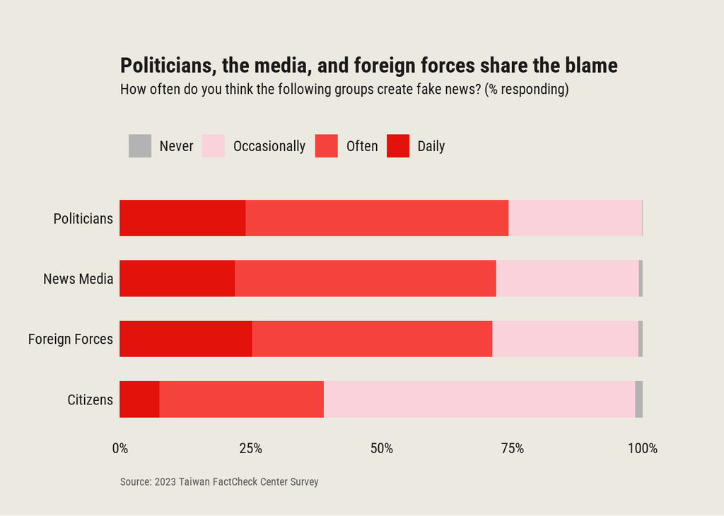

```r
plot_q4_stacked <-
    ggplot(
        q4_summary_pct,
        aes(x = pct, y = Source_en, fill = Freq_en)) +

    geom_col(width = 0.6) +

    scale_fill_manual(values = c("Daily" = econ_red,
                                 "Often" = econ_red60,
                                 "Occasionally" = econ_red_tok90,
                                 "Never" = econ_grey_lon70)) +

    scale_x_continuous(labels = percent_format(accuracy = 1),
                       expand = expansion(mult = c(0, 0.1))) +

    labs(
        title = "Politicians, the media, and foreign forces share the blame",
        subtitle = "How often do you think the following groups create fake news? (% responding)",
        x = NULL, y = NULL,
        caption = "Source: 2023 Taiwan FactCheck Center Survey") +

    theme_minimal() +

    theme(text = element_text(family = "roboto_condensed", color = text_lon10),

    legend.position = "top",
    legend.justification = "left",
    legend.title = element_blank(),
    legend.text = element_text(size = 20),
    legend.color = text_lon10,
    # legend.margin = margin(b = -10), # 縮小圖例跟圖表之間的距離

    plot.title = element_text(face = "bold",
                              size = 30,
                              hjust = 0,
                              margin = margin(t = 15, b = 5)),

    plot.subtitle = element_text(size = 20,
                                 hjust = 0,
                                 margin = margin(b = 20)),

    plot.caption = element_text(size = 15,
                                color = caption,
                                hjust = 0,
                                margin = margin(t = 15)),

    axis.text.y = element_text(size = 20, color = text_lon10),
    axis.text.x = element_text(size = 20, color = text_lon10),

    panel.grid = element_blank(),
    plot.background = element_rect(fill = econ_canvas_los90, color = NA),
    panel.background = element_rect(fill = econ_canvas_los90, color = NA),
    plot.margin = margin(t = 25, r = 20, b = 20, l = 20)
    )

plot_q4_stacked
```

## 3.4 請問您認為以下個人或團體是否經常在製造假消息？ - 境外勢力（Q4_4）X 政黨傾向（QASide）

```r
cross_politics_foreign <- clean_recode %>%
    mutate(

        Politics_en = case_when(
            QASide_factor == "非常接近泛藍" ~ "Strong KMT",
            QASide_factor == "接近泛藍" ~ "Lean KMT",
            QASide_factor == "接近泛綠" ~ "Lean DPP",
            QASide_factor == "非常接近泛綠" ~ "Strong DPP"),
        Politics_en = factor(Politics_en, levels = c("Strong DPP", "Lean DPP", "Strong KMT", "Lean KMT"))) %>%

    count(Politics_en, Q4_4_en) %>%
    group_by(Politics_en) %>%
    mutate(pct = n / sum(n)) %>%
    ungroup()

cross_politics_foreign
```

```
#> # A tibble: 16 × 4
#>    Politics_en Q4_4_en          n     pct
#>    <fct>       <ord>        <int>   <dbl>
#>  1 Strong DPP  Never            2 0.0141
#>  2 Strong DPP  Occasionally    13 0.0915
#>  3 Strong DPP  Often           53 0.373
#>  4 Strong DPP  Daily           74 0.521
#>  5 Lean DPP    Never            5 0.00556
#>  6 Lean DPP    Occasionally   207 0.230
#>  7 Lean DPP    Often          429 0.477
#>  8 Lean DPP    Daily          258 0.287
#>  9 Strong KMT  Never            3 0.03
#> 10 Strong KMT  Occasionally    33 0.33
#> 11 Strong KMT  Often           40 0.4
#> 12 Strong KMT  Daily           24 0.24
#> 13 Lean KMT    Never            5 0.00772
#> 14 Lean KMT    Occasionally   247 0.381
#> 15 Lean KMT    Often          299 0.461
#> 16 Lean KMT    Daily           97 0.150
```

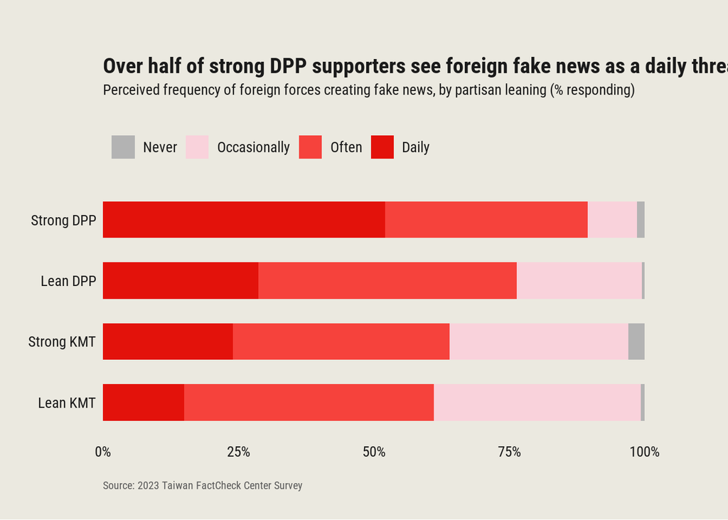

```r
plot_partisan_gap <-
    ggplot(
        cross_politics_foreign,
        aes(x = pct, y = fct_rev(Politics_en), fill = Q4_4_en)) +

    geom_col(width = 0.6) +

    scale_fill_manual(values = c("Daily" = econ_red,
                                 "Often" = econ_red60,
                                 "Occasionally" = econ_red_tok90,
                                 "Never" = econ_grey_lon70)) +

    scale_x_continuous(labels = percent_format(accuracy = 1),
                       expand = expansion(mult = c(0, 0.1))) +

    labs(
        title = "Over half of strong DPP supporters see foreign fake news as a daily threat",
        subtitle = "Perceived frequency of foreign forces creating fake news, by partisan leaning (% responding)",
        x = NULL, y = NULL,
        caption = "Source: 2023 Taiwan FactCheck Center Survey") +

    theme_minimal() +

    theme(
        text = element_text(family = "roboto_condensed", color = text_lon10),

        legend.position = "top",
        legend.justification = "left",
        legend.title = element_blank(),
        legend.text = element_text(size = 20),
        legend.color = text_lon10,

        plot.title = element_text(face = "bold",
                                  size = 30,
                                  hjust = 0,
                                  margin = margin(t = 15, b = 5)),

        plot.subtitle = element_text(size = 20,
                                     hjust = 0,
                                     margin = margin(b = 20)),

        plot.caption = element_text(size = 15,
                                    color = caption,
                                    hjust = 0,
                                    margin = margin(t = 15)),

        axis.text.y = element_text(size = 20, color = text_lon10),
        axis.text.x = element_text(size = 20, color = text_lon10),

        panel.grid = element_blank(),
        plot.background = element_rect(fill = econ_canvas_los90, color = NA),
        panel.background = element_rect(fill = econ_canvas_los90, color = NA),
        plot.margin = margin(t = 25, r = 20, b = 20, l = 20)
  )

plot_partisan_gap
```

## 3.5 請問您認為以下個人或團體是否經常在製造假消息？ - 政治人物（Q4_2）X 最高學歷（QA4）

```r
cross_edu_politicians <- clean_recode %>%
    # 回答 Never 的人比例太低
    filter(Q4_2_en != "Never") %>%

    mutate(
        Edu_en = case_when(
            QA4_factor == "高中職及以下" ~ "High school or below",
            QA4_factor == "大專" ~ "College",
            QA4_factor == "研究所及以上" ~ "Graduate or above"),

        Edu_en = factor(Edu_en, levels = c("Graduate or above", "College", "High school or below" ),
                        ordered = TRUE),

        Q4_2_en = fct_drop(Q4_2_en)) %>%

    count(Edu_en, Q4_2_en) %>%
    group_by(Edu_en) %>%
    mutate(pct = n / sum(n)) %>%
    ungroup()

cross_edu_politicians
```

```
#> # A tibble: 9 × 4
#>   Edu_en               Q4_2_en          n   pct
#>   <ord>                <ord>        <int> <dbl>
#> 1 Graduate or above    Occasionally    91 0.222
#> 2 Graduate or above    Often          209 0.510
#> 3 Graduate or above    Daily          110 0.268
#> 4 College              Occasionally   283 0.257
#> 5 College              Often          552 0.501
#> 6 College              Daily          267 0.242
#> 7 High school or below Occasionally    83 0.303
#> 8 High school or below Often          138 0.504
#> 9 High school or below Daily           53 0.193
```

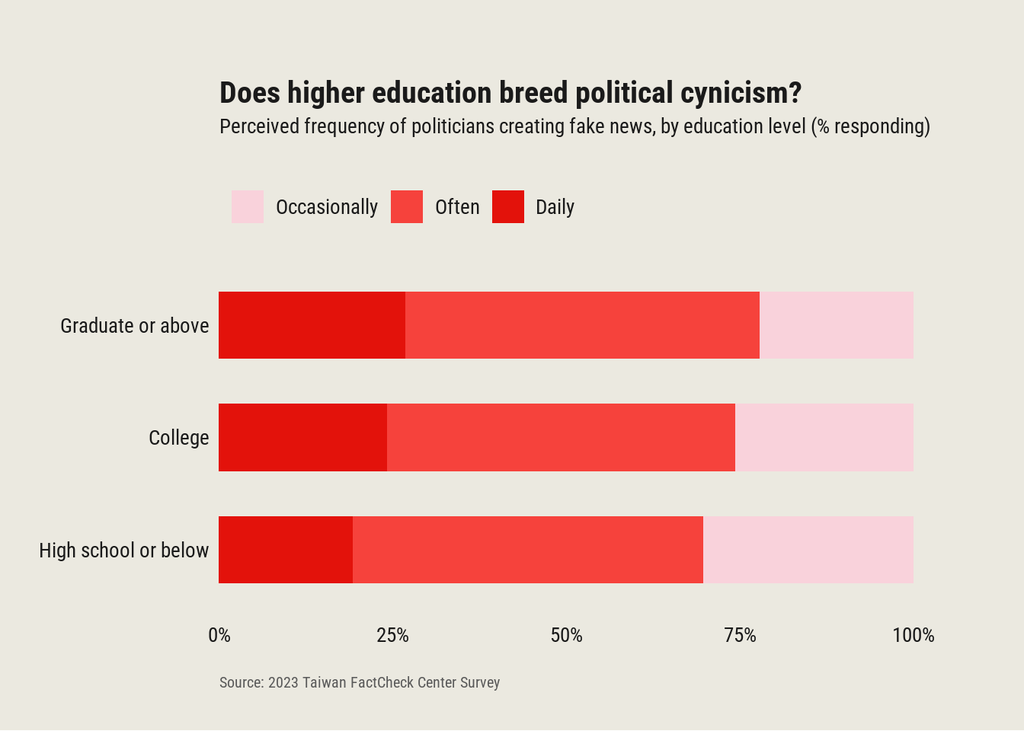

```r
plot_edu_gap <-
    ggplot(
        cross_edu_politicians,
        aes(x = pct, y = fct_rev(Edu_en), fill = Q4_2_en)) +

    geom_col(width = 0.6) +

    scale_fill_manual(values = c("Daily" = econ_red,
                                 "Often" = econ_red60,
                                 "Occasionally" = econ_red_tok90)) +

    scale_x_continuous(labels = percent_format(accuracy = 1),
                       expand = expansion(mult = c(0, 0.1))) +

    labs(
        title = "Does higher education breed political cynicism?",
        subtitle = "Perceived frequency of politicians creating fake news, by education level (% responding)",
        x = NULL, y = NULL,
        caption = "Source: 2023 Taiwan FactCheck Center Survey") +

    theme_minimal() +

    theme(
        text = element_text(family = "roboto_condensed", color = text_lon10),

        legend.position = "top",
        legend.justification = "left",
        legend.title = element_blank(),
        legend.text = element_text(size = 20),
        legend.color = text_lon10,

        plot.title = element_text(face = "bold",
                                  size = 30,
                                  hjust = 0,
                                  margin = margin(t = 15, b = 5)),

        plot.subtitle = element_text(size = 20,
                                     hjust = 0,
                                     margin = margin(b = 20)),

        plot.caption = element_text(size = 15,
                                    color = caption,
                                    hjust = 0,
                                    margin = margin(t = 15)),

        axis.text.y = element_text(size = 20, color = text_lon10),
        axis.text.x = element_text(size = 20, color = text_lon10),

        panel.grid = element_blank(),
        plot.background = element_rect(fill = econ_canvas_los90, color = NA),
        panel.background = element_rect(fill = econ_canvas_los90, color = NA),
        plot.margin = margin(t = 25, r = 20, b = 20, l = 20)
        )

plot_edu_gap
```